# Bonanza Creek Experimental Forest Snowshoe Hares (SILVA)

German Silva

11/8/2021

# Introduction

This report looks at juvenile snowshoe hares, *Lepus americanus*, from a study done in Bonanza Creek Long-term Ecological Research (LTER) site in Alaska by Kielland *et al*. (2017). Snowshoe hares are an important prey species in northern boreal forest systems and have a cyclical population cycle (fluctuating every 8-11 years). Kielland *et al*.’s purpose was to try to determine population metrics at the landscape scale for juvenile snowshoe hares. In this report you will find an overview of the number of juvenile hares trapped, the difference in body mass across sites and sex, and the analysis of the relationship between hare hind foot length and body mass.

# Data and Analyses

The data used in this report comes from Kielland *et al*.’s 2017 update of a study looking at snowshoe hares in Bonanza Creek LTER in Alaska. The variables from the data set that are the focus of this report are the hares’ age (juvenile or not), weight (g), sex, hind foot length (hindft, mm), and site of trapping (grid). Three main analyses were preformed: 1) number of juveniles trapped over time, 2) body mass between sexes and across sites, and 3) the relationship between hind foot length and body mass. Main statistical techniques used to accomplish theses analyses include: 1) histograms, 2) qqplots, 3) descriptive statistics (mean, median, max, standard deviation, etc.), 4) boxplots, and 5) linear models (and associated diagnostics).

# Juvenile Snowshoe Hare Data Exploration

## Juvenile Snowshoe Hare Trappings Over Time

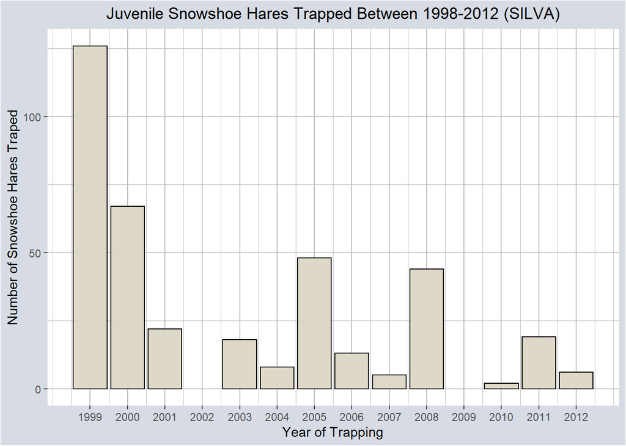

**Figure 1** Bar graph showing the amount of juvenile snowshoe hares trapped in Bonanza Creek Experimental Forest over time between 1999 and 2012. The largest number of trappings occured in 1999.

The number of juvenile snowshoe hares trapped ranged from 126 in 1999 to 2 in 2010. The average number of trapped juveniles is 31.5, with a median of 18.5. There is a general trend of a decreasing number of juveniles being trapped since 1999. To standardize the number of trappings (due to effort), trapping campaigns should be a set length of 5 days with a standard number of traps (n=30) with traps being checked twice daily and hares being measured whenever encountered.

## Sex Differences in Juvenile Snowshoe Hare Weight

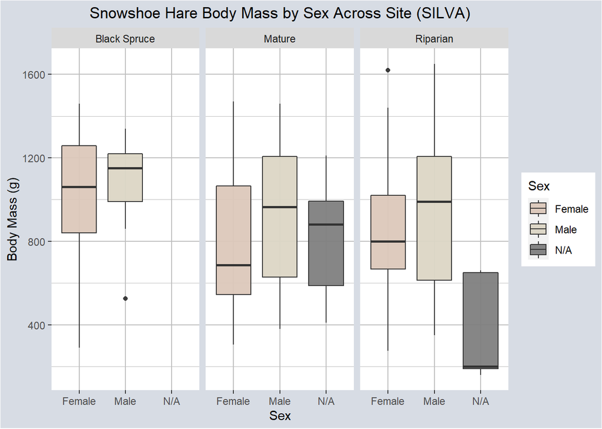

**Figure 2** Boxplots showing distributions of body mass in grams for male and female snowshoe hares across sites. Boxes represent the middle 50% of all weight observations per site.

The boxplots show that there is a difference in body mass between sexes and across sites in the juvenile snowshoe hares trapped and measured. Median body mass for male hares is greater than that of female hares across sites. However, hares trapped in Black Spruce site had a greater median body mass than those caught at other sites.

Table 1 Snowshoe Hare Body Mass Summary Statistics

| Sex | Mean Body Mass (g) | Standard Deviation (g) | Sample Size |
| --- | --- | --- | --- |
| f | 855.39 | 292.25 | 200 |
| m | 945.86 | 333.22 | 163 |
| NA | 614.55 | 357.59 | 15 |

There are several ways that we can determine that the body mass of male and female snowshoe hares are different. First, we can directly compare mean body mass. Male snowshoe hares have a mean of 945.86 g, while females have a mean body mass of 855.39 g (a difference of 90.47 g; Table 1). Second, we can use Cohen’s d to see how many standard deviations apart the two means are. A Cohen’s d of 0.29 shows that the two group means are 0.29 standard deviations apart, indicating that there is a difference between the two groups but it is hard to tell by if we looked at histograms of the data. Third is a t-test comparing the two groups. A t-test returns a p-value of 0.007 meaning that if male and female juvenile snowshoes hares had the same mean body mass, there is a 0.7% chance that we would draw a sample with means at least this different. As this is below a 95% confidence level, we would reject that their means are the same as that probability is too unlikely. All comparisons indicate that there is a statistically significant and true difference in body mass between male and female snowshoe hares.

## Is there a relationship between Juvenile Snowshoe Hare Body Mass and Hind Foot Length?

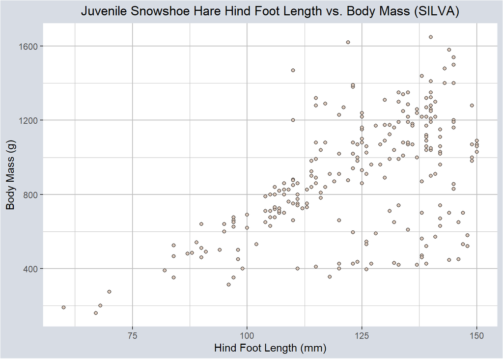

**Figure 3** Scatter plot showing hind foot length (mm) vs. body mass (g) for juvenile snowshoe hares. General shape of the plot implies a positive relationship is present between the two variables.

When preforming a linear regression, the formula:
$$\operatorname{\widehat{weight}} = -279.34 + 9.52(\operatorname{hindft})$$
is used to describe the relationship between snowshoe hare hind foot length and body mass, with an R<sup>2</sup> of 0.299, and a Pearson’s r value of 0.547. We would interpret the slope coefficient of 9.52 to mean that on average we would expect for every millimeter increase in hind foot length that body mass would increase by 9.52 g, the R<sup>2</sup> value as 29.9% of the variance between the two variables is explained by the model, and Pearson’s r as 54.7% of the change in body mass is explained by a change in hind foot length. Diagnostic plots indicate that residual normality and homoscedasticity maybe a concern when performing a linear model between these two variables. A linear model does not capture the frame of the relationship well due to the potential violation of assumptions and the moderate to low explanation in change and variance between the two variables by the model itself.

# Summary

In summary:

- A large number of trappings occurred in 1999, with a general trend of fewer hares being trapped as time went on
- There is a statistically significant difference between male and female body mass (p-value = 0.007)
  - Boxplots imply that there is also a difference between median body mass across sites, especially Black Spruce vs the Bonanza mature and riparian sites
- There is a moderate positive correlation between hind foot length and hare body mass (r = 0.547)
  - However, a linear model may not be the best representation of this relationship due to potential violation of assumptions (determined from diagnostic plots) and low explanatory power for variance by the model (R<sup>2</sup> = 0.299)

# References

Anderson, Daniel, Heiss, Andrew and Sumners, Jay (2021). “equatiomatic: Transform Models into ‘LaTeX’ Equations.” R package version 0.3.0. https://CRAN.R-project.org/package=equatiomatic

Bui, An, Lowman, Heili, Guerra, Ana Sofia, and Miller-ter Kuile, Ana (2021). “calecopal: A California-inspired Package of Color Palettes.” R package version 0.1.0.

Firke, Sam (2021). “janitor: Simple Tools for Examining and Cleaning Dirty Data.” R package version 2.1.0. https://CRAN.R-project.org/package=janitor

Grolemund, Garrett and Wickham, Hadley (2011). “Dates and Times Made Easy with lubridate. Journal of Statistical Software, 40(3), 1-25. URL https://www.jstatsoft.org/v40/i03/

Kielland, K., F.S. Chapin, R.W. Ruess, and Bonanza Creek LTER (2017). “Snowshoe hare physical data in Bonanza Creek Experimental Forest: 1999-Present ver 22.” Environmental Data Initiative. https://doi.org/10.6073/pasta/03dce4856d79b91557d8e6ce2cbcdc14

Müller, Kirill (2020). “here: A Simpler Way to Find Your Files.” R package version 1.0.1. https://CRAN.R-project.org/package=here

Robinson, David, Hayes, Alex and Couch, Simon (2021). “broom: Convert Statistical Objects into Tidy Tibbles.” R package version 0.7.10. https://CRAN.R-project.org/package=broom

Wickham et al., (2019). “Welcome to the tidyverse.” Journal of Open Source Software, 4(43), 1686, https://doi.org/10.21105/joss.01686

Zhu, Hao (2021). “kableExtra: Construct Complex Table with ‘kable’ and Pipe Syntax.” R package version 1.3.4. https://CRAN.R-project.org/package=kableExtra